# Presidential Returns Across 150 Years

Forty-one elections in one file, and the question of whether the country was always divided this evenly

Democracy’s Data

Last updated September 13, 2026 at 10:53a EDT

Every presidential election now ends the same way: on a knife edge. The 2024 winner led the two-party vote — the votes cast for the Democratic and Republican candidates, all others set aside — by 1.5 points, and commentary treats that as the permanent condition of American politics — a country locked at fifty-fifty. Has presidential politics always been this close?

The answer matters to more than trivia. A close election is one where a campaign has to ask people for their votes, and a foregone one is an election where nobody asks. Whether the country has always sat near an even split, and whether close national elections have always meant close states, decides who gets courted and who gets ignored. Both questions can be answered from the returns.

## The test

The data is state-level returns for all 41 presidential elections from 1864 to 2024, with the national popular vote alongside them, gathered by Jason Timm into *PresElectionResults*, a collection he publishes on GitHub and anyone can download at https://github.com/jaytimm/PresElectionResults. No federal source exists, because the United States has never had a national election authority. The collection is built from Wikipedia’s per-election articles, which rest on Dave Leip’s *Atlas of U.S. Presidential Elections* (https://uselectionatlas.org/) and, beneath that, the official state canvasses — each state’s formal tally of its own returns.

This source fits the question because a claim about eras needs a series that is consistent across eras. Consistency is exactly what a compiler supplies and what fifty-one separate state archives do not. The cost is that a compilation inherits the reliability of its weakest link without marking which link that was. A row for Louisiana in 1872 and a row for Michigan in 2020 are formatted identically, and they are not the same kind of object. What a certified return can bear, and what no return can, is the subject of this cluster’s chapter on election returns.

## The data

One row of the state file is one state in one presidential election. The national file carries one row per candidate per election. The columns, by name:

| File | Column | What it holds |
| --- | --- | --- |
| `pres_states_1864_2024.csv` | `year`, `state_abbrev` | the election and the state |
|  | `democrat`, `republican`, `other` | each side’s share of the vote, as a percentage |
|  | `winner`, `party_win` | who carried the state, and their party |
| `pres_national.csv` | `candidate`, `party` | one line per national candidate |
|  | `pop_votes`, `pop_per` | their popular vote, and its share |
|  | `ec_votes`, `ec_total` | their electoral votes, and that year’s total |

Little was done to the file, and what was done is worth knowing. Its 1,913 rows were counted and its column names checked against what the compilation promises before anything was trusted; the columns above were kept and the rest set aside. Nothing was repaired: where a share is missing it stays missing. Two rows show why that restraint matters.

| Year | State | Dem % | Rep % | Other % | Winner |
| --- | --- | --- | --- | --- | --- |
| 1864 | CA | 41.4 | 58.60 | NA | Abraham Lincoln |
| 1948 | AL | NA | 19.04 | 79.75 | Strom Thurmond |

The 1864 row is ordinary. In the 1948 row Alabama’s Democratic share is `NA`, the file’s mark for a missing value: not zero, not small, but absent. The state party had replaced the national ticket with the Dixiecrats — the States’ Rights Democrats who broke from the party over civil rights that year — so no slate pledged to Harry Truman was on the ballot.[^1] Filling that blank with zero would record that no Alabamian wanted to vote for Harry Truman, which is untrue. Deleting the row would erase an election in which the party system was breaking. The file’s 19 rows like it, where a major party had no ballot line, are recoverable only because the blank was left alone.

Coverage changes too. The file holds 25 states in 1864, because eleven were in armed rebellion, and nothing in the file says so — it just has fewer rows. Every comparison across time is therefore a comparison between different sets of states. Finally, these are shares rather than vote counts. The margin used below is the winner’s lead in the **two-party vote**: their percentage of the votes cast for the two major parties, minus the loser’s. It is computed on this page rather than baked into the file, and the arithmetic is short. In 2024 the Republican ticket had 77,302,580 votes and the Democratic ticket 75,017,613; of the 152,320,193 votes the two cast together, those are shares of 50.8% and 49.2%, and the difference between them is the 1.5-point margin the first sentence of this brief quoted.

> **Before you look at any figure, write down two numbers.** In 1960, how many of the fifty states finished within five points of an even split? And in 2024, out of fifty-one? Commit to both before you read on.

## What it says about democracy

Start with the country as a whole. Figure 1 draws the winner’s national two-party margin in every election since 1864. It is one line on a time axis because the claim under test is a claim about eras, and an era is a stretch of that line.

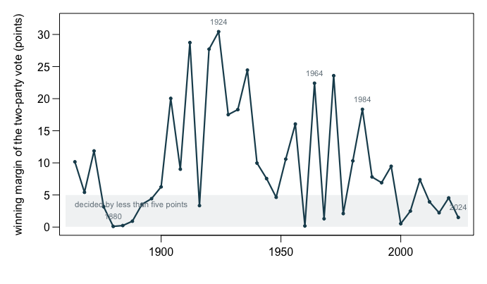

Move across the chart for each election’s margin and who led it.

**Figure 1. The winner’s margin of the national two-party vote, 1864–2024.** Each point is one election; the shaded band marks a margin under five points. Hover for the year and the candidate who led. The line spends the middle of the twentieth century far above the band and the last three decades inside or near it.

The current era is real. The margin has been under five points in 6 of the 7 elections since 2000, and no candidate has won the two-party vote by ten points since 1984. That is 10 consecutive elections without a double-digit winner, the longest such run in the record; the previous record was 7.

It is also historically unusual, and the file says exactly how unusual. Between 1904 and 1984 the average margin was 14.6 points; since 1988 it has been 4.7. The blowouts cluster into eras: the 1920s, when Harding and then Coolidge won by 27.7 and 30.4 points, Roosevelt’s 24.5 in 1936, and the landslides of 1964, 1972 and 1984, each above 18 points. For most of the twentieth century, a presidential election was not close.

There is one true exception, and it deserves its story. From 1876 to 1896, 6 straight elections came in under five points, inside a run of 7 without a double-digit winner. That was the Gilded Age, and 1880 was decided by 0.1 points of the two-party vote.[^2] Sustained near-tie politics has happened before, exactly once. A second caution: the two-party margin can mislead where a third candidate mattered. In 1912 it reads 28.7 points, yet Wilson took only 41.8% of all votes cast, because the margin ignores Roosevelt’s Progressives entirely.

| Year | States within 5 points | States in the union | % competitive |
| --- | --- | --- | --- |
| 1896 | 14 | 45 | 31.1 |
| 1924 | 8 | 48 | 16.7 |
| 1960 | 33 | 50 | 66.0 |
| 1976 | 31 | 51 | 60.8 |
| 2000 | 21 | 51 | 41.2 |
| 2024 | 13 | 51 | 25.5 |

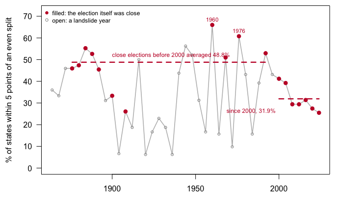

Filled points are the 18 elections in which the average state sat within three points of an even split. Hollow points are landslides, where few states are close anywhere. Hover for the count.

**Figure 2. The share of states decided within five points, election by election.** Filled points mark the 18 elections in which the average state sat within three points of an even split, so that a landslide cannot be blamed for an empty battleground. Among those close elections, 48.8% of states were competitive before 2000 and 31.9% since.

Here the two eras of national closeness come apart. In 1960, 33 of 50 states were within five points of even. In 2024 it was 13 of 51. Most of the sawtooth in Figure 2 is the national result, because a landslide leaves nothing close anywhere. The filled points strip that explanation out: they hold the national margin fixed, and the battleground still shrinks. **The modern near-tie era is unusual twice over: the country has never been this close for this long, and it has never been this close with so few close states.**

The old form of that condition had a name. For roughly eighty years after Reconstruction, the Democratic share of the two-party vote in the eleven Confederate states ran far above the rest of the country, peaking 41.7 points higher in 1924. A third of the country was conceded in advance, and the returns record the concession as ordinary arithmetic. That gap first turned negative in 1964 and has stayed negative in every election since 1984. The concession did not end; it moved, lost its regional name, and by 2024 covered a larger share of the states than it did in 1960.

## What this brief cannot tell you

**Shares are not votes.** The state file carries no vote counts and no turnout, so a five-point margin in Wyoming and a five-point margin in California are the same number here and nothing like the same event. The only national figures the state file supports are unweighted averages across states, which is why Figure 1 is built from the national file instead.

**A margin measures the electorate that was allowed to exist.** Post-1877 Southern returns are accurate counts of elections conducted under systematic disenfranchisement — poll taxes, literacy tests and registration rules written to keep Black citizens, and many poor white ones, off the rolls.[^3] The numbers are real; what they measure is not what a 2024 return measures, and no arithmetic on this file can correct for it.

**The two-party margin hides third parties.** 1912, 1968 and 1992 all look tamer here than they were, and 1912 looks like a blowout that never happened.

**The file cannot say why margins narrowed.** It dates the eras; it cannot explain them. Candidate explanations, from party sorting to nationalized media to the end of the Solid South, need evidence below the level of a state total, and this file has nothing below a state.

## What you should have learned

- The winner’s national two-party margin has been under five points in 6 of the 7 elections since 2000, and no winner has reached ten points in 10 straight elections — the longest run in the record.
- Sustained near-tie politics has one precedent: 6 straight sub-five-point elections from 1876 to 1896, including 1880’s 0.1-point margin.
- Between those eras, blowouts were the norm: the average margin from 1904 to 1984 was 14.6 points, against 4.7 since 1988.
- Close countries no longer mean close states: 33 of 50 states sat within five points of even in 1960, against 13 of 51 in 2024.
- A blank is data: the 19 rows where a major party had no ballot line survive only because `NA` was left as `NA` instead of being written as zero.

## Extensions

None of these is answered above, and every one can be answered from the tables the Sources section hands over.

- `pres_national.csv` carries `pop_per` and `ec_votes` side by side. Find the elections where a modest popular-vote share became an electoral-vote landslide. Which eras produce the biggest gaps between the two columns?
- `pres_states_1864_2024.csv` has an `other` column that is often missing rather than zero. Count the years where it is missing everywhere. What is the difference between a third party getting no votes and nobody recording them?
- Pick one state in `pres_states_1864_2024.csv` and follow its `democrat` column from 1864 to 2024. When did it last change the side it favored, and how does that year compare with its neighbors?
- `pres_national.csv` has an `ec_total` column that changes across the series. Find every year it changes and say what has to happen in the country for that number to move.

Two stretch ideas point past the spreadsheet. Dave Leip’s *Atlas* (https://uselectionatlas.org/) publishes county returns for modern elections; pull one battleground state’s counties for 2024 and check whether a close state is close everywhere or an average of blowouts. And when the 2028 returns are certified, the collection will grow by one election — download it again and see whether the streak in Figure 1 extends.

## Sources

**Data**

- Jason Timm, *PresElectionResults* (https://github.com/jaytimm/PresElectionResults), state series and national popular and electoral vote, compiled from per-election sources resting ultimately on Dave Leip’s *Atlas of U.S. Presidential Elections* (https://uselectionatlas.org/) and the official state canvasses.

**Historical literature**

- Kousser, J. Morgan (1974). *The Shaping of Southern Politics: Suffrage Restriction and the Establishment of the One-Party South, 1880–1910.* Yale University Press. — the disenfranchisement behind the Southern returns. https://yalebooks.yale.edu/book/9780300019735/the-shaping-of-southern-politics/

**The data itself**

Every figure above is drawn from these tables. They are plain CSV, they open in a spreadsheet, and they are yours to take further.

`pres_states_1864_2024.csv`, `pres_national.csv`

Rebuild this data yourself, with an AI assistant

```
I want to rebuild two public datasets from their original source,
without any starting files. Please do the following and show your
work.

THE SOURCE. Jason Timm's PresElectionResults collection on GitHub,
served raw from
https://raw.githubusercontent.com/jaytimm/PresElectionResults/master/data/
Download two files: pres_by_state.rda, state-level presidential returns
from 1864 to 2024, and pres_results.rda, the national popular and
electoral vote by candidate back to 1824. Both are .rda files -- R's
own data format -- so read them in R, or with a library that opens R
data files. No account or key is needed. The state series is
compiled from public per-election records that themselves rest on
fifty-one separate official sources. Treat the deep past with more
caution than the recent past: nineteenth-century "popular vote"
totals rest on state records of wildly varying quality, and in 1864
eleven states were in armed rebellion and did not vote at all.

WHAT TO BUILD.
1. One row per state per election: the Democratic, Republican, and
   other shares, and who won the state.
2. One row per candidate per election nationally: electoral votes,
   the electoral-college total for that year, popular votes, and
   the popular-vote share.

CHECK YOUR WORK. The copies this book used were downloaded in August
2026. If your rebuild matches them, you should find:
- 1,913 state rows spanning the 41 elections from 1864 to 2024
- 101 national candidate lines from 1824 to 2024
- for 2024: Trump 312 electoral votes of 538 and 77,302,580 popular
  votes, against 226 and 75,017,613 for Harris
The collection grows by one election every four years, and past
years can be touched up as records are reconciled; small drift means
a revision upstream, not an error in your work.
```

[^1]: Encyclopedia of Alabama, “Dixiecrats,” https://encyclopediaofalabama.org/article/dixiecrats/.
[^2]: James A. Garfield over Winfield Scott Hancock; the National Archives keeps the certified electoral and popular tallies at https://www.archives.gov/electoral-college/1880.
[^3]: J. Morgan Kousser, *The Shaping of Southern Politics: Suffrage Restriction and the Establishment of the One-Party South, 1880–1910* (New Haven: Yale University Press, 1974), https://yalebooks.yale.edu/book/9780300019735/the-shaping-of-southern-politics/.